# Reproducible Research: Peer Assessment #1

## Loading and preprocessing the data

```r
#load packages that may be useful for analysis

library(ggplot2)
library(dplyr)
library(tidyr)
library(lubridate)
library(xtable)

#After forking and cloning the repository, set the working directory to the local copy of the repository. Unzip the file and then read the csv into R. The date is reformatted.

unzip("activity.zip")
activity<-read.csv("activity.csv")

activity$date<-ymd(activity$date)
```

## What is the mean total number of steps taken per day?

```r
#Code will make the sum total of steps taken per day, then a histogram of the number of steps per day with the base plotting system, and finally produce a table of the mean and median steps per day

activity_by_day<-activity%>%
        group_by(date)%>%
        summarise(steps=sum(steps))


#overall mean across days
mean(activity_by_day$steps, na.rm=TRUE)
```

[1] 10766.19

```r
#overall median across days
median(activity_by_day$steps, na.rm=TRUE)
```

[1] 10765

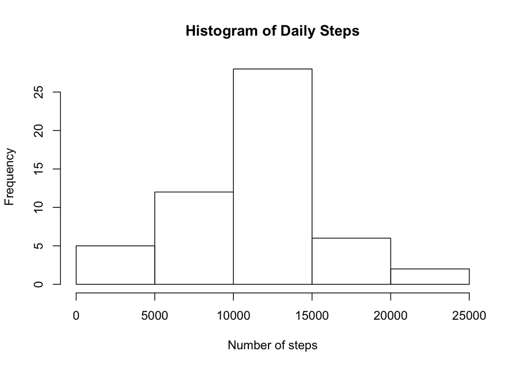

```r
hist(activity_by_day$steps, xlab="Number of steps", main="Histogram of Daily Steps")
```

```r
#The dates will be converted into a character so they work in the xtable
mean_and_median_steps<-activity%>%
        group_by(as.character(date))%>%
        summarise(mean=mean(steps, na.rm=TRUE),
                  median=median(steps, na.rm=TRUE))



mean_and_median_steps<-xtable(mean_and_median_steps, digits=0)

print(mean_and_median_steps, type="html", include.rownames = FALSE)
```

| as.character(date) | mean | median |
| --- | --- | --- |
| 2012-10-01 |  |  |
| 2012-10-02 | 0 | 0 |
| 2012-10-03 | 39 | 0 |
| 2012-10-04 | 42 | 0 |
| 2012-10-05 | 46 | 0 |
| 2012-10-06 | 54 | 0 |
| 2012-10-07 | 38 | 0 |
| 2012-10-08 |  |  |
| 2012-10-09 | 44 | 0 |
| 2012-10-10 | 34 | 0 |
| 2012-10-11 | 36 | 0 |
| 2012-10-12 | 60 | 0 |
| 2012-10-13 | 43 | 0 |
| 2012-10-14 | 52 | 0 |
| 2012-10-15 | 35 | 0 |
| 2012-10-16 | 52 | 0 |
| 2012-10-17 | 47 | 0 |
| 2012-10-18 | 35 | 0 |
| 2012-10-19 | 41 | 0 |
| 2012-10-20 | 36 | 0 |
| 2012-10-21 | 31 | 0 |
| 2012-10-22 | 47 | 0 |
| 2012-10-23 | 31 | 0 |
| 2012-10-24 | 29 | 0 |
| 2012-10-25 | 9 | 0 |
| 2012-10-26 | 24 | 0 |
| 2012-10-27 | 35 | 0 |
| 2012-10-28 | 40 | 0 |
| 2012-10-29 | 17 | 0 |
| 2012-10-30 | 34 | 0 |
| 2012-10-31 | 54 | 0 |
| 2012-11-01 |  |  |
| 2012-11-02 | 37 | 0 |
| 2012-11-03 | 37 | 0 |
| 2012-11-04 |  |  |
| 2012-11-05 | 36 | 0 |
| 2012-11-06 | 29 | 0 |
| 2012-11-07 | 45 | 0 |
| 2012-11-08 | 11 | 0 |
| 2012-11-09 |  |  |
| 2012-11-10 |  |  |
| 2012-11-11 | 44 | 0 |
| 2012-11-12 | 37 | 0 |
| 2012-11-13 | 25 | 0 |
| 2012-11-14 |  |  |
| 2012-11-15 | 0 | 0 |
| 2012-11-16 | 19 | 0 |
| 2012-11-17 | 50 | 0 |
| 2012-11-18 | 52 | 0 |
| 2012-11-19 | 31 | 0 |
| 2012-11-20 | 16 | 0 |
| 2012-11-21 | 44 | 0 |
| 2012-11-22 | 71 | 0 |
| 2012-11-23 | 74 | 0 |
| 2012-11-24 | 50 | 0 |
| 2012-11-25 | 41 | 0 |
| 2012-11-26 | 39 | 0 |
| 2012-11-27 | 47 | 0 |
| 2012-11-28 | 35 | 0 |
| 2012-11-29 | 24 | 0 |
| 2012-11-30 |  |  |

The chart above shows a histogram of the number of the total number of steps per day. The table produced shows the mean and median number of steps. Those days without data are shown as blanks in the resulting table.

## What is the average daily activity pattern?

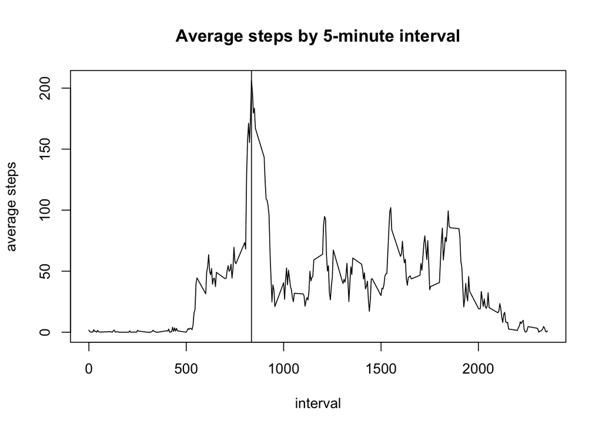

```r
mean_interval<-activity%>%
        group_by(interval)%>%
        summarise(mean_steps=mean(steps, na.rm=TRUE))

plot(x=mean_interval$interval, y=mean_interval$mean_steps, type="l", xlab="interval", ylab="average steps", main="Average steps by 5-minute interval")
abline(v=835)
```

Based on the plot above, the interval with the highest number of steps is the 835th.

## Imputing missing values

As seen in the table by day, there are several data points missing (2,304 to be exact). These will be updated using the average for that 5-minute interval.

Once updated, the mean and median remained effectively the same.

```r
#Count the number of intervals with missing values
sum(is.na(activity$steps))
```

[1] 2304

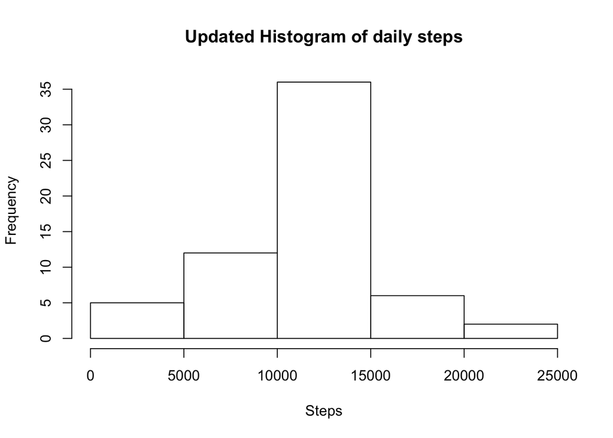

```r
#merge the mean dataframe and the original activity. Then update missing values with the mean for the period.

mean_interval<-data.frame(mean_interval)
activity_update<-merge(activity, mean_interval, by.x = "interval"
      ,by.y="interval")

activity_update$steps<-ifelse(is.na(activity_update$steps), activity_update$mean_steps,
                              activity_update$steps)


#Sum the total steps per day
activity_update_day<-activity_update%>%
        group_by(date)%>%
        summarise(steps=sum(steps))

#Produce an updated histogram of steps
hist(activity_update_day$steps, main="Updated Histogram of daily steps", xlab="Steps")
```

```r
#Updated daily mean

mean(activity_update_day$steps)
```

[1] 10766.19

```r
# Updated daily median

median(activity_update_day$steps)
```

[1] 10766.19

```r
#Updated table of the mean and median per day

Updated_mean_and_median_steps<-activity_update%>%
        group_by(as.character(date))%>%
        summarise(mean=mean(steps, na.rm=TRUE), median=median(steps, na.rm=TRUE))

Updated_mean_and_median_steps<-xtable(Updated_mean_and_median_steps, digits=0)
print(Updated_mean_and_median_steps, type="html", include.rownames = FALSE)
```

| as.character(date) | mean | median |
| --- | --- | --- |
| 2012-10-01 | 37 | 34 |
| 2012-10-02 | 0 | 0 |
| 2012-10-03 | 39 | 0 |
| 2012-10-04 | 42 | 0 |
| 2012-10-05 | 46 | 0 |
| 2012-10-06 | 54 | 0 |
| 2012-10-07 | 38 | 0 |
| 2012-10-08 | 37 | 34 |
| 2012-10-09 | 44 | 0 |
| 2012-10-10 | 34 | 0 |
| 2012-10-11 | 36 | 0 |
| 2012-10-12 | 60 | 0 |
| 2012-10-13 | 43 | 0 |
| 2012-10-14 | 52 | 0 |
| 2012-10-15 | 35 | 0 |
| 2012-10-16 | 52 | 0 |
| 2012-10-17 | 47 | 0 |
| 2012-10-18 | 35 | 0 |
| 2012-10-19 | 41 | 0 |
| 2012-10-20 | 36 | 0 |
| 2012-10-21 | 31 | 0 |
| 2012-10-22 | 47 | 0 |
| 2012-10-23 | 31 | 0 |
| 2012-10-24 | 29 | 0 |
| 2012-10-25 | 9 | 0 |
| 2012-10-26 | 24 | 0 |
| 2012-10-27 | 35 | 0 |
| 2012-10-28 | 40 | 0 |
| 2012-10-29 | 17 | 0 |
| 2012-10-30 | 34 | 0 |
| 2012-10-31 | 54 | 0 |
| 2012-11-01 | 37 | 34 |
| 2012-11-02 | 37 | 0 |
| 2012-11-03 | 37 | 0 |
| 2012-11-04 | 37 | 34 |
| 2012-11-05 | 36 | 0 |
| 2012-11-06 | 29 | 0 |
| 2012-11-07 | 45 | 0 |
| 2012-11-08 | 11 | 0 |
| 2012-11-09 | 37 | 34 |
| 2012-11-10 | 37 | 34 |
| 2012-11-11 | 44 | 0 |
| 2012-11-12 | 37 | 0 |
| 2012-11-13 | 25 | 0 |
| 2012-11-14 | 37 | 34 |
| 2012-11-15 | 0 | 0 |
| 2012-11-16 | 19 | 0 |
| 2012-11-17 | 50 | 0 |
| 2012-11-18 | 52 | 0 |
| 2012-11-19 | 31 | 0 |
| 2012-11-20 | 16 | 0 |
| 2012-11-21 | 44 | 0 |
| 2012-11-22 | 71 | 0 |
| 2012-11-23 | 74 | 0 |
| 2012-11-24 | 50 | 0 |
| 2012-11-25 | 41 | 0 |
| 2012-11-26 | 39 | 0 |
| 2012-11-27 | 47 | 0 |
| 2012-11-28 | 35 | 0 |
| 2012-11-29 | 24 | 0 |
| 2012-11-30 | 37 | 34 |

The median data point is now higher for several days once NA data has been updated.

## Are there differences in activity patterns between weekdays and weekends?

While weekends do not have the large spike, they have generally more steps across periods.

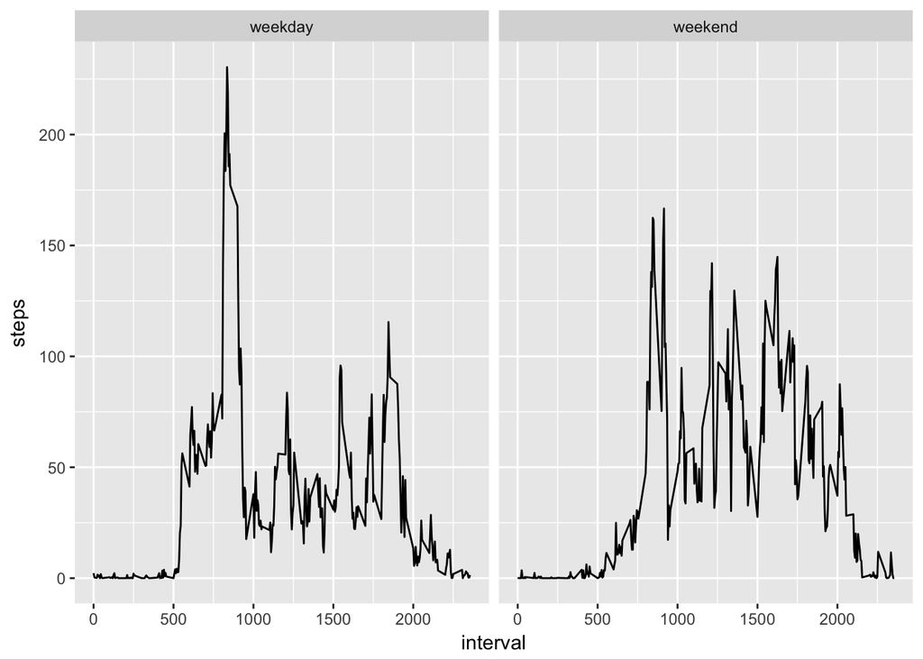

```r
#create a variable that indicates whether it is a weekday or weekend.

activity_update$day.of.week<-weekdays(activity_update$date)
activity_update$weekend<-ifelse(activity_update$day.of.week
                                =="Saturday"| activity_update$day.of.week=="Sunday", "weekend", "weekday")

daily_updated<-activity_update%>%
        group_by(interval, weekend)%>%
        summarise(steps=mean(steps))%>%
        ggplot(aes(x=interval,y=steps))+geom_line()+facet_grid(.~weekend)

daily_updated
```